# 4.2_gamma-gamma_coincidence_II

## 4.2 二维对称矩阵的本底-Radware approch

### 二维矩阵

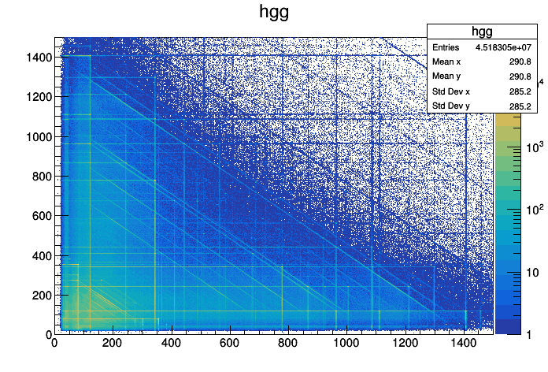

```python
TCanvas *c1=new TCanvas;
TFile *fgamma=new TFile("eu152gg.root");
TH2D *hgg=(TH2D*)fgamma->Get("hgg");
hgg->Draw("colz");
gPad->SetLogz();
c1->Draw();
```

```python
.L peaks.C
```

### 总投影谱- total projection spectrum

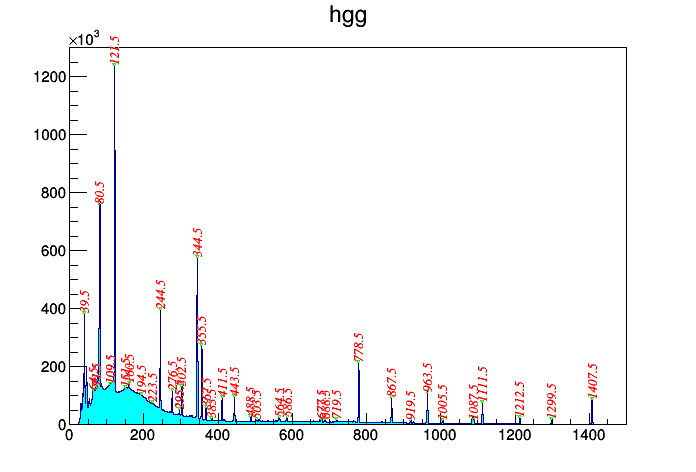

```python
TH1D *hg=hgg->ProjectionX("hg");
peaks("hg");
c1->Draw();
```

### 152Eu decay

- X-ray - through EC of 152Eu follows by the emission of a characterisitic x-ray of 152Sm

| X-ray | Energy(keV) | Intensity |
| --- | --- | --- |
| XR kα2 | 39.522 | 21.0 % |
| XR kα1 | 40.118 | 37.7 % |
| XR kβ3 | 45.293 | 3.75 % |
| XR kβ1 | 45.414 | 7.26 % |
| XR kβ2 | 46.578 | 2.40 % |

- $\gamma -$ ray 参考 作业4.1内衰变纲图

### 总投影谱的peaks和background

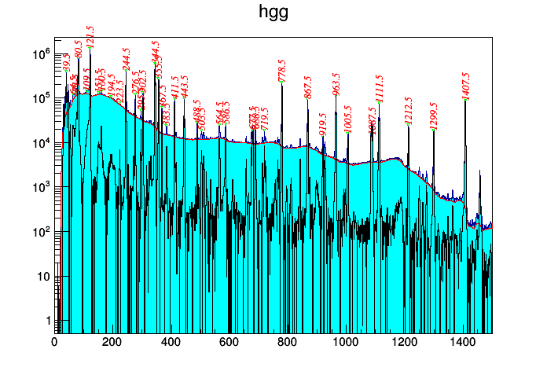

```python
TSpectrum *sa=new TSpectrum(200);
TH1D *hbg,*hpeak;
//Generate Smooth Background under peaks.
hbg=(TH1D*)sa->Background(hg,8,"nosmoothing same");//background
hbg->SetFillColor(kWhite);
hpeak=new TH1D("hpeak","hpeak",1500,0,1500);
hpeak->Add(hg,hbg,1,-1);//peaks
hpeak->SetLineColor(kBlack);
hpeak->Draw("same");
gPad->SetLogy();
c1->Draw();
```

### Radware method：Background Substraction in $M_{ij}$ gg matrix

- D.C. Radford, Nucl. Instr. Meth. A361(1995)306

For $i_{th}$ bin of the total 1D projection of two-fold coincidence matrix $M_{ij}$, the total counts $𝑃_i$ can be divided into a “background” spectrum $b_i$ and a “peak” spectrum $p_i$ : $P_i=b_i+p_i$。The background counts underlying the peaks arise from both Compton-scattered γ-rays and quasi-continuum transitions.

[figure not shown]

$$P_i=\sum_{j} M_{ij}, \quad T=\sum_{j}P_j $$

For the two-fold background matrix $B_{ij}$:

$$b_i=\sum_{j} B_{ij} $$$$b_i= b_i \frac{\sum_{j} P_j}{T} =\sum_{j}{\frac{1}{T} b_i P_j}$$

$$B_{ij}=\frac{1}{T}b_i P_j=\frac{1}{T}b_i(p_j+b_j)=\frac{1}{T}(b_i p_j+b_i b_j)$$

But the term of $b_j p_i$ is not include in the equation above, so that $B_{ij}$ is asymmetric. The symmetric 2D background can be written as: $$B_{ij}=\frac{1}{T}(b_i p_j+b_j p_i+b_i b_j)=\frac{1}{T}(P_i P_j-p_i p_j)$$

- 上述方法可以推广到 3-fold，4-fold的矩阵

### 其他方法：

- G. Palameta and J.C. Waddington, Nucl. Instr. Meth. A234(1985)476
- TSpectrum2的Background()方法
  - https://root.cern.ch/doc/master/classTSpectrum2.html

### Radware方法的具体实现

```python
TH2D* hggb=new TH2D("hggb","bgmat for gg",1500,0,1500,1500,0,1500);
TH2D* hggmat=new TH2D("hggmat","ggmat with backsub",1500,0,1500,1500,0,1500);
Double_t T,Pi,Pj,pi,pj,Bij,x,y;
```

```python
T=hg->Integral();
  for(int i=0;i<hgg->GetNbinsX();i++) {
    for(int j=0;j<hgg->GetNbinsY();j++) {
      Pi=hg->GetBinContent(i+1);
      Pj=hg->GetBinContent(j+1);
      pi=hpeak->GetBinContent(i+1);
      pj=hpeak->GetBinContent(j+1);
      Bij=(Pi*Pj-pi*pj)/T;
      if(Bij<0) Bij=0;
      x=hg->GetBinCenter(i+1);
      y=hg->GetBinCenter(j+1);
      hggb->Fill(x,y,Bij);// backgound gg matix
    }
  }

  hggmat->Add(hgg,hggb,1,-1);// background subtracted gg matix.
```

### 本底$\gamma-\gamma$矩阵

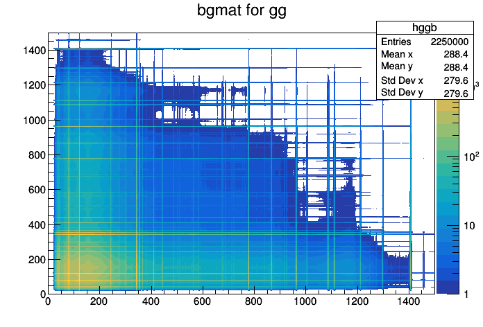

```python
hggb->Draw("colz");
c1->SetLogy(0);
c1->SetLogz();
c1->Draw();
```

### 减本底后的$\gamma-\gamma$矩阵

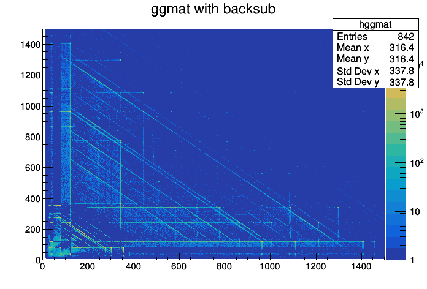

```python
hggmat->Draw("colz");
c1->SetLogy(0);
c1->SetLogz();
c1->Draw();
```

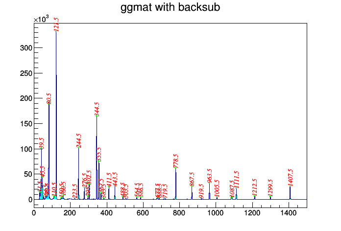

```python
TH1D *hgx=hggmat->ProjectionX("hgx");
peaks("hgx");
c1->Draw();
```

### 观察矩阵的局部

```python
.L zoom.C
```

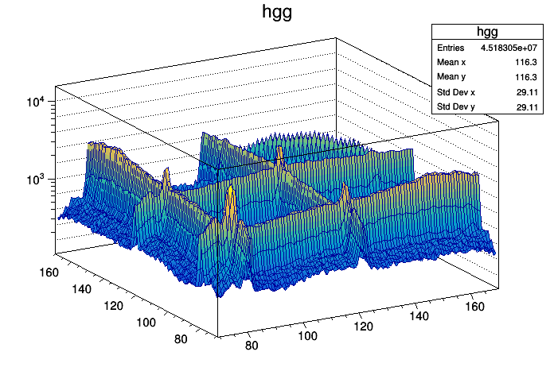

```python
zoom("hgg",70,70,100);
c1->Draw();//Draw(“surf1”);
```

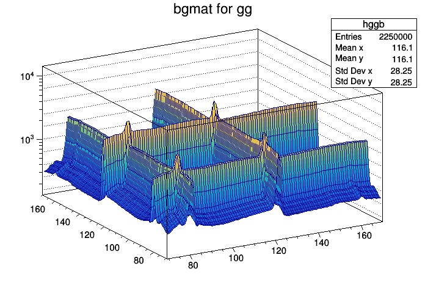

```python
zoom("hggb",70,70,100);
c1->Draw();
```

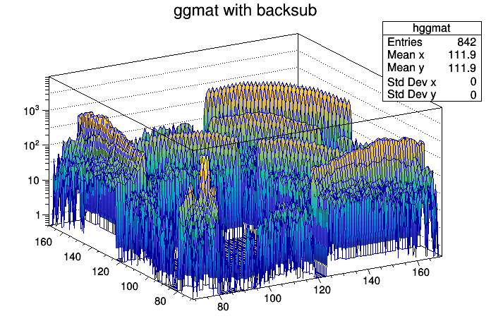

```python
zoom("hggmat",70,70,100);
c1->Draw();
c1->Draw();
```

#### 减本底后的矩阵的每个(x,y)位置的高度计数的统计误差增加！

$\sigma_{N_{net}}=\sqrt{\sigma^2_N+\sigma^2_{background}} $

#### 当剩余计数$N_{net}$与统计误差$\sigma_{N_{net}}$大小相近时无法判断是否有符合！

- 只有尽量减少本底贡献，才能确认弱关联的gamma之间的符合关系
  - 途径：
    - 每个探测器加入anti-compton shield
    - 通过加入其它探测器的符合，选择感兴趣的反应道。。。

```python
void gate(Double_t ge, TH2D* hgg, Double_t xmax=1500,Double_t gew=2)
{   int ih=0;
    double gea,geb;
    TH1D *hg;
    TString hname;
    hgg->SetAxisRange(0,xmax,"X");
    hgg->SetAxisRange(0,xmax,"Y");
    gea=hgg->GetXaxis()->FindBin(ge-gew);
    geb=hgg->GetXaxis()->FindBin(ge+gew);
    hname.Form("gated on %d keV_%i",int(ge),ih++);
    hg=hgg->ProjectionX(hname,gea,geb);
    hg->SetTitle(hname);
    hg->Sumw2(0);
    hg->SetAxisRange(0,1500,"X");
    peaks(hname,0.02);
    c1->Draw();
}
```

### 122keV的开窗谱

- 152Eu中和121keV有符合的gamma射线：244、296、444 ... keV

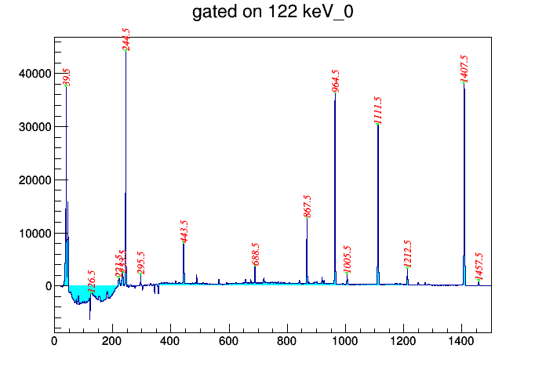

```python
gate(122.5,hggmat);
```

# Interactive Generation of level scheme

- Assume a tentative level scheme with branching ratios for different transitions
- Predict the projected spectra in coincidence with gates
- Compare with the observed intensity of g-lines
- Adjust branching ratios to fit counts in peak
- Add new levels & transitions if required
- Continue until satisfied !!
- Spin & parity from angular correlation/polarization data

## 验证133Ba的衰变纲图

### x-ray

- through EC of 133Ba follows by the emission of a characterisitic x-ray of 133Cs

| X-ray | Energy(keV) | Intensity |
| --- | --- | --- |
| XR kα2 | 30.625 | 33.9 % |
| XR kα1 | 30.973 | 62.2 % |
| XR kβ3 | 34.92 | 5.88 % |
| XR kβ1 | 34.987 | 11.4 % |
| XR kβ2 | 35.818 | 3.51 % |

### $\gamma-$ ray

Each level decay through $\gamma$ and IC(Internal Conversion) with intensity of $I_{\gamma}$ and $I_{e}$, respectively.

[figure not shown]

### 预期符合关系

| gate \ peaks | 80 | 160 | 223 | 302 | 383 | 53 | 276 | 356 |
| --- | --- | --- | --- | --- | --- | --- | --- | --- |
| 80 | O | x | O | O | x | O | O | O |
| 223 | O | O | x | x | x | O | x | x |
| 160 | x | x | O | x | x | O | O | x |
| 302 | O | x | x | x | x | O | x | x |
| 383 | O | x | x | x | x | O | x | x |
| 53 | O | O | O | O | O | x | x | x |
| 276 | O | O | x | x | x | x | x | x |
| 356 | O | x | x | x | x | x | x | x |

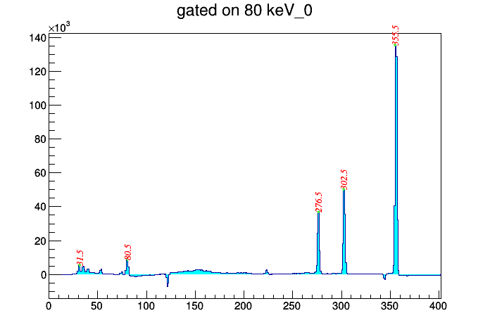

```python
//%jsroot on
gate(80,hggmat,400);//80:53,80!,223,276,302,356, no 160!
```

| gate \ peaks | 80 | 160 | 223 | 302 | 383 | 53 | 276 | 356 |
| --- | --- | --- | --- | --- | --- | --- | --- | --- |
| 80 | O | x | O | O | x | O | O | O |

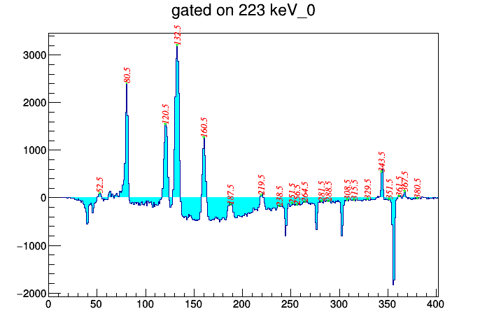

```python
gate(223,hggmat,400);//223:53,80,160 -> 80+80=160
```

| gate \ peaks | 80 | 160 | 223 | 302 | 383 | 53 | 276 | 356 |
| --- | --- | --- | --- | --- | --- | --- | --- | --- |
| 80 | O | x | O | O | x | O | O | O |
| 223 | O | O | x | x | x | O | x | x |

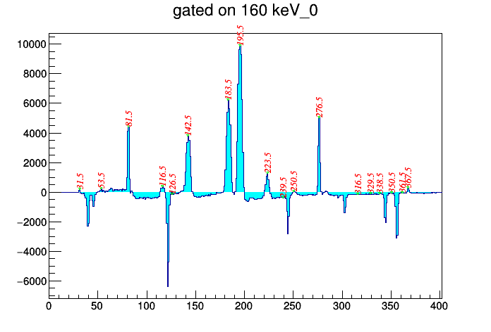

```python
gate(160,hggmat,400);//160:53,80,276
```

| gate \ peaks | 80 | 160 | 223 | 302 | 383 | 53 | 276 | 356 |
| --- | --- | --- | --- | --- | --- | --- | --- | --- |
| 80 | O | x | O | O | x | O | O | O |
| 223 | O | O | x | x | x | O | x | x |
| 160 | O->x | x | O | x | x | O | O | x |

gate(80)没有160峰，gate(160)有80峰：80和160没有符合

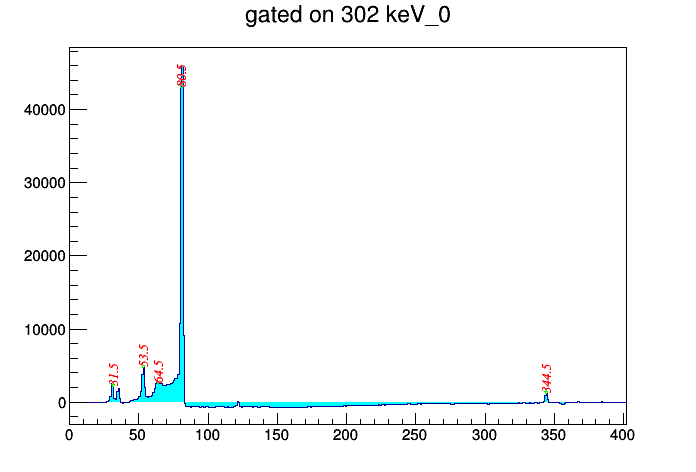

```python
gate(302,hggmat,400);//302:53,80
```

| gate \ peaks | 80 | 160 | 223 | 302 | 383 | 53 | 276 | 356 |
| --- | --- | --- | --- | --- | --- | --- | --- | --- |
| 80 | O | x | O | O | x | O | O | O |
| 223 | O | O | x | x | x | O | x | x |
| 160 | O->x | x | O | x | x | O | O | x |
| 302 | O | x | x | x | x | O | x | x |

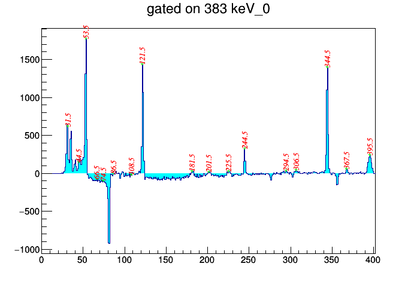

```python
gate(383,hggmat,400);//383:53
```

[output not shown]

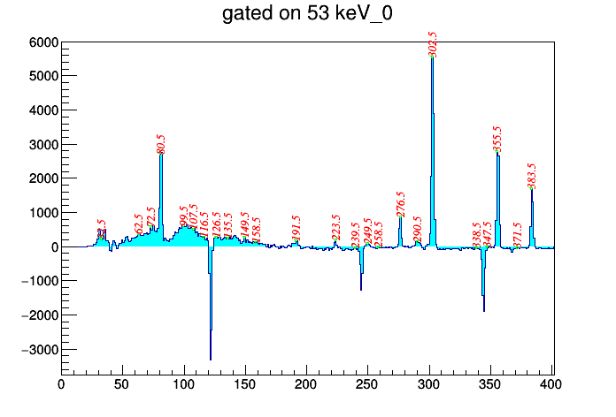

```python
gate(53,hggmat,400);//53:80,223,302,383: 223+80=302, 80+302=382,
```

[output not shown]

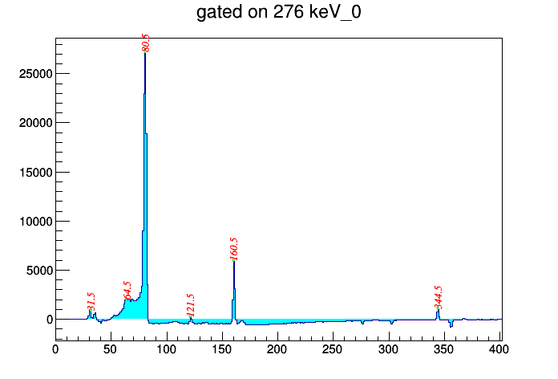

```python
gate(276,hggmat,400);//276:80,160
```

[output not shown]

- 276-53没有符合！

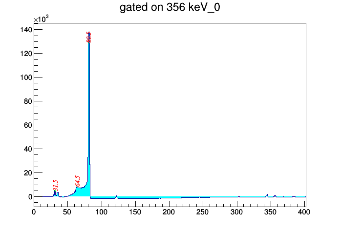

```python
gate(356,hggmat,400);//356:80
```

### 观察符合得到的关联关系

[output not shown]

### 预期符合关系

| gate \ peaks | 80 | 160 | 223 | 302 | 383 | 53 | 276 | 356 |
| --- | --- | --- | --- | --- | --- | --- | --- | --- |
| 80 | O | x | O | O | x | O | O | O |
| 223 | O | O | x | x | x | O | x | x |
| 160 | x | x | O | x | x | O | O | x |
| 302 | O | x | x | x | x | O | x | x |
| 383 | O | x | x | x | x | O | x | x |
| 53 | O | O | O | O | O | x | x | x |
| 276 | O | O | x | x | x | x | x | x |
| 356 | O | x | x | x | x | x | x | x |

### 说明

- 53keV与160keV的符合关系与预期不一致。

  当两个gamma之间相隔越远(中间相隔的gamma较多)时，由于中间路径中其他gamma分流强度，两者之间的符合强度很小。 当统计不强的时候，不容易看见他们之间的直接符合。 因此gamma开窗谱，一般用于确定相隔不远的gamma之间的符合关系。 根据附近gamma之间的关联，以及gamma能量之间的加合和强度平衡关系，猜测可能的符合关系。按照上述步骤，逐步验证和修订，最终建立能级纲图。
- 一般同轴型HPGe的效率在200keV附近为峰值，在50keV附近效率很低。
- 根据上述讨论和实际观察到的gamma之间的关联，可以确认53keV-160keV有符合关系。
- 二维，三维γ矩阵分析程序 GATE2，GATE3：https://github.com/zhihuanli/gamma-gamma-coincidence-analysis

### 偶然符合矩阵

```
在熔合蒸发反应γ谱学实验中，低能区通常会观察到来自实验靶的衬底成分（如Au或Pb）的X射线峰，例如图b、c中的68、79和279keV附近的峰。这些X射线是由于被束流激发的衬底原子在退激时产生的。与熔合蒸发反应产物的γ-γ之间不同的是，X射线和γ射线之间没有符合关系（不相关）。然而，由于X射线的生成截面远大于γ射线的生成截面，在γ−γ符合时间窗内会混入显著的偶然符合成分(见图a)。

可以通过构建偶然符合矩阵，按照下述步骤去除符合时间窗内的偶然符合成分。
首先，将符合时间窗范围内的γ符合事件填入瞬发符合矩阵PAM（Prompt+Accindental Matrix）中。然后，在符合时间窗范围外选取左右对称的两个偶然符合时间窗（图a中红色阴影区），将该区域的事件填入偶然符合本底矩阵AM（Accindental Matrix）。通过将PAM矩阵减去AM矩阵得到最终的矩阵PM（Prompt Matrix）：设符合时间窗长度为dPT，偶然符合窗总长度dAT，则 PM = PAM - (dPT/dAT) * AM。

经验表明，所选偶然符合时间窗距离符合时间窗越近，其偶然符合事件的扣除效果越好。原则上，偶然符合时间窗的选择应紧挨着符合时间窗的两个对称时间窗。图b和c展示了扣除偶然符合前后的投影谱对比图。粉色表示未扣除偶然符合的投影谱，而蓝色表示扣除偶然符合后的投影谱。可以看出，通过偶然符合的扣除，197Au的X射线影响大大减少。
```

[figure not shown]